# Human and economic cost of major weather events in the USA

##### Results

Loading ggplot2 and xtable library for drawing the plots and creating html tables for the data used

```r
library(ggplot2)
library(xtable)
```

Setting up and printing the plot for Fatalities

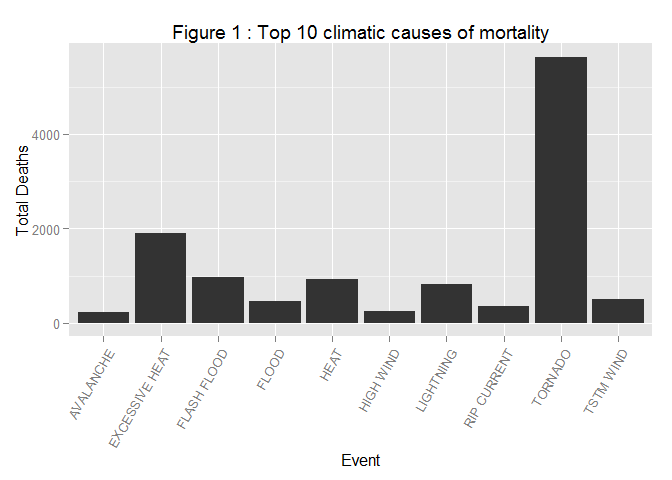

```r
p1 <- ggplot(topFa , aes(x = EVTYPE, y = FATALITIES)) +
      geom_bar(stat = "identity") +
      theme(axis.text.x = element_text(angle = 60, hjust = 1))+
        labs(title = "Figure 1 : Top 10 climatic causes of mortality",
      x = "Event", y = "Total Deaths")

print(p1)
```

```r
htopFa<-xtable(topFa[1:10,])
print(htopFa,type='html')
```

|  | EVTYPE | FATALITIES |
| --- | --- | --- |
| 834 | TORNADO | 5633.00 |
| 130 | EXCESSIVE HEAT | 1903.00 |
| 153 | FLASH FLOOD | 978.00 |
| 275 | HEAT | 937.00 |
| 464 | LIGHTNING | 816.00 |
| 856 | TSTM WIND | 504.00 |
| 170 | FLOOD | 470.00 |
| 585 | RIP CURRENT | 368.00 |
| 359 | HIGH WIND | 248.00 |
| 19 | AVALANCHE | 224.00 |

Table 1 : Fatalities due to weather events

Setting up and printing the plot for Injuries

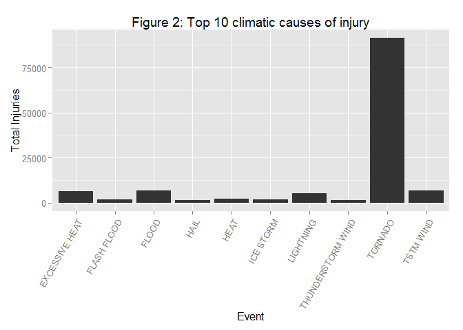

```r
p2 <- ggplot(topInj , aes(x = EVTYPE, y = INJURIES)) +
        geom_bar(stat = "identity") +
        theme(axis.text.x = element_text(angle = 60, hjust = 1))+
        labs(title = "Figure 2: Top 10 climatic causes of injury",
        x = "Event", y = "Total Injuries")

print(p2)
```

```r
htopInj<-xtable(topInj[1:10,])
print(htopInj,type='html')
```

|  | EVTYPE | INJURIES |
| --- | --- | --- |
| 834 | TORNADO | 91346.00 |
| 856 | TSTM WIND | 6957.00 |
| 170 | FLOOD | 6789.00 |
| 130 | EXCESSIVE HEAT | 6525.00 |
| 464 | LIGHTNING | 5230.00 |
| 275 | HEAT | 2100.00 |
| 427 | ICE STORM | 1975.00 |
| 153 | FLASH FLOOD | 1777.00 |
| 760 | THUNDERSTORM WIND | 1488.00 |
| 244 | HAIL | 1361.00 |

Table 2 : Injuries due to weather events

Setting up the ggplot and printing top categories of damage in $ Billions

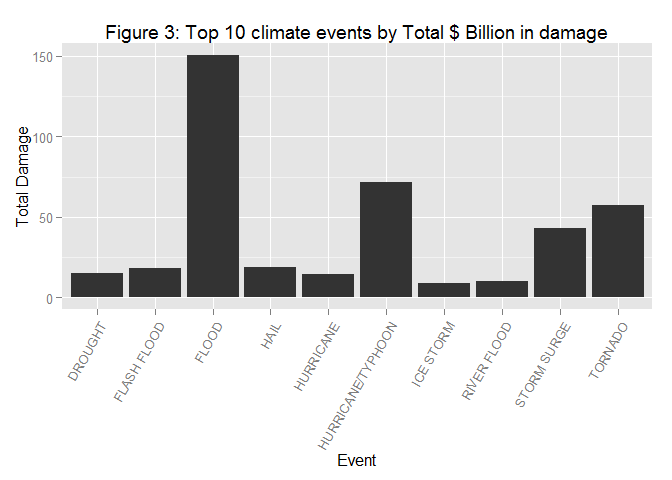

```r
p3 <- ggplot(topTd , aes(x = EVTYPE, y = TOTDMG/10^9)) +
      geom_bar(stat = "identity") +
      theme(axis.text.x = element_text(angle = 60, hjust = 1))+
      labs(title = "Figure 3: Top 10 climate events by Total $ Billion in damage",
      x = "Event", y = "Total Damage")

print(p3)
```

```r
htopTd<-xtable(topTd[1:10,])
print(htopTd,type='html')
```

|  | EVTYPE | TOTDMG |
| --- | --- | --- |
| 170 | FLOOD | 150319678320.00 |
| 411 | HURRICANE/TYPHOON | 71913712800.00 |
| 834 | TORNADO | 57362337155.00 |
| 670 | STORM SURGE | 43323541000.00 |
| 244 | HAIL | 18761224827.00 |
| 153 | FLASH FLOOD | 18243995295.00 |
| 95 | DROUGHT | 15018672000.00 |
| 402 | HURRICANE | 14610229010.00 |
| 590 | RIVER FLOOD | 10148404500.00 |
| 427 | ICE STORM | 8967041810.00 |

Table 3 : Damage due to weather events